# Tarea Módulo III - Machine Learning con R

Félix Rodríguez Lagonell

### Introducción

En este informe haremos un estudio del dataset Student.zip para estudiantes de matemáticas: https://archive.ics.uci.edu/ml/machine-learning-databases/00320/student.zip

Descrito en: https://archive.ics.uci.edu/ml/datasets/Student+Performance

En primer lugar nos basaremos en un análisis en componentes principales (PCA) para intentar condensar la información del dataset en un pequeño conjunto de variables. Nuestro objetivo es descubrir la posible relación entre variables usando métodos de aprendizaje automático. Compararemos estos resultados con el modelo de clustering K-Means.

Posteriormente intentaremos predecir la variable G3 (nota final) con los modelos supervisados KNN y SVM.

### Descarga y lectura de datos

El subdirectorio “datos” quedará creado en el directorio de trabajo actual, desde el que se esté ejecutando el script.

```r
if (! "knitr" %in% installed.packages()) install.packages("knitr", dependencies=TRUE)
if (! "dplyr" %in% installed.packages()) install.packages("dplyr", dependencies=TRUE)
if (! "factoextra" %in% installed.packages()) install.packages("factoextra", dependencies=TRUE)
if (! "corrplot" %in% installed.packages()) install.packages("corrplot", dependencies=TRUE)

library(knitr)
library(dplyr)
library(factoextra)
library(corrplot)

if (!file.exists("./datos")) {
        dir.create("./datos")
  fileURL <- "https://archive.ics.uci.edu/ml/machine-learning-databases/00320/student.zip"
  download.file(fileURL,destfile="./datos/student.zip",method="curl")
  unzip("./datos/student.zip", exdir="./datos")
}

mat <- read.table("./datos/student-mat.csv",
                         row.names=NULL, sep=";", header=TRUE)
#por <- read.table("./datos/student-por.csv",
#                         row.names=NULL, sep=";", header=TRUE)
```

### Análisis PCA

Para llevar a cabo el estudio con el algoritmo PCA, debemos eliminar de nuestro conjunto de datos las variables categóricas, pues nuestro modelo sólo es válido con variables numéricas.

```r
mat1 <- select_if(mat, is.numeric)
kable(head(mat1))
```

| age | Medu | Fedu | traveltime | studytime | failures | famrel | freetime | goout | Dalc | Walc | health | absences | G1 | G2 | G3 |
| --- | --- | --- | --- | --- | --- | --- | --- | --- | --- | --- | --- | --- | --- | --- | --- |
| 18 | 4 | 4 | 2 | 2 | 0 | 4 | 3 | 4 | 1 | 1 | 3 | 6 | 5 | 6 | 6 |
| 17 | 1 | 1 | 1 | 2 | 0 | 5 | 3 | 3 | 1 | 1 | 3 | 4 | 5 | 5 | 6 |
| 15 | 1 | 1 | 1 | 2 | 3 | 4 | 3 | 2 | 2 | 3 | 3 | 10 | 7 | 8 | 10 |
| 15 | 4 | 2 | 1 | 3 | 0 | 3 | 2 | 2 | 1 | 1 | 5 | 2 | 15 | 14 | 15 |
| 16 | 3 | 3 | 1 | 2 | 0 | 4 | 3 | 2 | 1 | 2 | 5 | 4 | 6 | 10 | 10 |
| 16 | 4 | 3 | 1 | 2 | 0 | 5 | 4 | 2 | 1 | 2 | 5 | 10 | 15 | 15 | 15 |

```r
dim(mat1)
```

[1] 395 16

Apliamos el algoritmo PCA mediante la función prcomp(). Con el argumento scale=TRUE centramos los datos y normalizamos a 1 la varianza.

```r
pca <- prcomp(mat1, scale=TRUE)
names(pca)
```

[1] “sdev” “rotation” “center” “scale” “x”

Esta función devuelve los siguientes valores:

- ‘center’ y ‘scale’ contienen la media y desviación típica de las variables previa estandarización (escala original).
- ‘rotation’ contiene el vector de pesos por cada componente. El producto del vector ‘rotation’ por nuestro conjunto de datos nos devuelve las coordenadas de los datos en el nuevo sistema rotado de coordenadas. Estos valores se calculan automáticamente con la función prcomp() y quedan guardados en pca$x.
- ‘x’ coordenadas en el nuevo sistema de referencia.

```r
#kable(head(pca$rotation))
#kable(head(pca$x))
dim(pca$x)
```

[1] 395 16

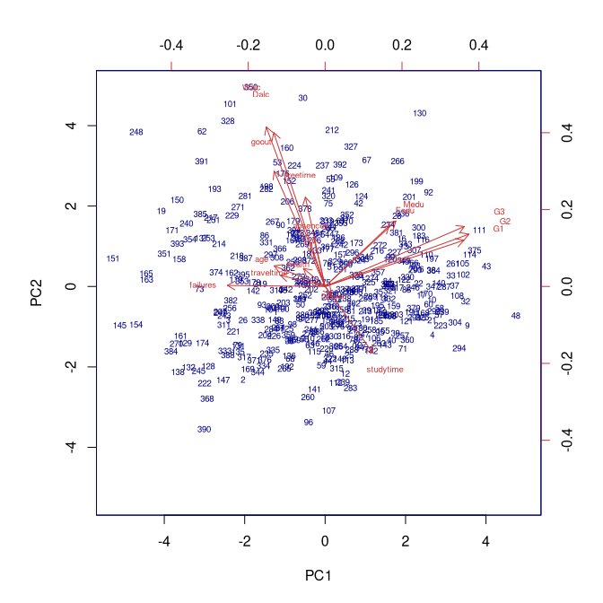

```r
biplot(pca, scale = 0, cex = 0.6, col = c("blue4", "brown3"))
```

Vemos que nuestro modelo no captura de manera óptima la diversidad del conjunto de variables. Este resultado se hace patente si evaluamos la varianza explicada por cada componente:

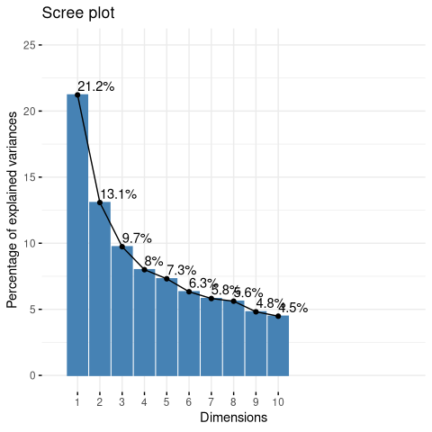

```r
# Varianza explicada por cada componente
#PVE <- 100*pca$sdev^2/sum(pca$sdev^2)

# Varianza acumulada por cada componente
#PVA <- cumsum(PVE)

fviz_screeplot(pca, addlabels = TRUE, xlim = c(0, 16), ylim = c(0, 25))
```

```r
#fviz_eig(rpca)
```

Así pues, necesitamos las 7 primeras componentes para explicar tan sólo el 70% de la varianza. Para explicar aproximadamente el 90% de la varianza necesitamos las primeras 11 componentes. Por lo tanto la necesidad de elección de una mayor cantidad de componentes para que el modelo se comporte adecuadamente nos da una medida cualitativa de la dispersión del conjunto de datos.

### Comparación de resultados con K-means

Veamos si obtenemos un buen resultado tras nuestro análisis PCA. En primer lugar calculamos el número de clusters óptimo mediante el método de “el codo” (elbow method)

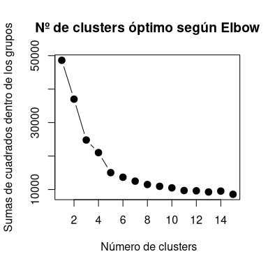

```r
wss <- (nrow(mat1)-1)*sum(apply(mat1, 2, var))
for (i in 2:15) wss[i] <- sum(kmeans(mat1, centers=i)$withinss)
plot(1:15, wss, type="b", xlab=" Número de clusters",
     ylab="Sumas de cuadrados dentro de los grupos",
     main="Nº de clusters óptimo según Elbow",
     pch=20, cex=2)
```

Agrupemos nuestro datos en base a 5 clusters:

```r
set.seed(8080)

# Conjunto de datos
k.mat1 <- kmeans(mat1, 5)
k.mat1
```

K-means clustering with 5 clusters of sizes 42, 5, 127, 72, 149

Cluster means: age Medu Fedu traveltime studytime failures famrel 1 17.04762 2.261905 2.214286 1.571429 1.976190 0.90476190 3.857143 2 17.80000 3.000000 3.000000 1.400000 2.000000 0.40000000 4.200000 3 16.40945 3.015748 2.748031 1.338583 2.141732 0.05511811 4.031496 4 17.18056 2.958333 2.500000 1.361111 1.875000 0.52777778 3.722222 5 16.57047 2.550336 2.409396 1.550336 2.040268 0.31543624 3.993289 freetime goout Dalc Walc health absences G1 1 3.095238 3.261905 1.333333 1.976190 3.690476 0.3809524 7.333333 2 2.200000 2.600000 1.400000 2.000000 3.600000 52.6000000 10.200000 3 3.307087 2.937008 1.354331 2.047244 3.496063 3.0472441 14.488189 4 3.347222 3.333333 1.763889 2.763889 3.486111 15.1944444 10.236111 5 3.194631 3.120805 1.496644 2.369128 3.597315 3.3221477 9.214765 G2 G3 1 4.738095 0.5238095 2 10.000000 9.4000000 3 14.582677 14.8346457 4 9.805556 9.9583333 5 9.563758 9.6912752

Clustering vector: [1] 5 1 4 3 5 3 5 5 3 3 5 5 3 5 3 3 3 5 4 5 3 3 3 3 5 4 5 3 5 4 5 3 3 5 3 [36] 5 3 3 5 3 4 5 3 5 4 5 4 3 3 5 3 3 5 5 5 5 3 3 5 3 5 5 5 5 5 3 3 5 5 3 [71] 3 5 1 3 2 5 5 5 5 4 5 5 4 3 5 5 5 3 4 4 5 3 5 5 3 5 3 5 3 5 4 3 3 4 3 [106] 4 5 3 5 3 3 5 5 3 5 3 3 3 4 3 3 3 3 4 5 3 5 5 1 3 1 1 4 4 1 1 1 1 3 3 [141] 1 5 5 3 1 5 1 5 1 5 1 3 5 1 5 5 3 5 3 5 1 5 1 5 5 4 5 3 1 3 1 3 5 1 5 [176] 5 3 5 4 5 4 3 3 2 4 4 5 3 5 5 4 5 4 5 3 3 3 5 4 5 3 5 5 4 5 4 5 4 5 5 [211] 4 4 3 4 4 3 4 4 5 5 1 1 3 3 3 4 3 5 4 4 4 5 4 3 4 4 3 4 5 1 4 5 1 3 1 [246] 3 3 4 1 3 5 5 5 5 5 5 3 4 3 1 4 5 3 5 1 3 5 5 4 1 4 3 5 3 5 5 2 4 4 5 [281] 4 4 5 5 5 5 3 3 3 3 4 3 4 3 3 3 1 4 3 3 4 5 3 3 4 3 3 2 3 4 1 4 5 4 4 [316] 2 1 5 5 5 4 4 5 3 3 5 3 5 5 3 5 3 1 1 1 4 4 1 3 5 5 1 3 1 5 3 3 5 3 4 [351] 5 3 5 5 5 5 3 5 5 3 3 3 5 3 5 5 3 1 5 4 5 3 5 4 3 5 3 5 3 4 3 5 5 1 4 [386] 5 5 1 5 1 4 3 5 5 5

Within cluster sum of squares by cluster: [1] 1385.976 965.600 4059.890 4377.097 4258.282 (between_SS / total_SS = 69.0 %)

Available components:

[1] “cluster” “centers” “totss” “withinss”  
[5] “tot.withinss” “betweenss” “size” “iter”  
[9] “ifault”

```r
# Conjunto de datos PCA
k.mat1.pca <- kmeans(pca$x[, 1:2], 5)
k.mat1.pca
```

K-means clustering with 5 clusters of sizes 61, 126, 30, 76, 102

Cluster means: PC1 PC2 1 -2.2452231 -1.1746810 2 0.1281575 -0.9714560 3 -3.1605348 1.8434840 4 -0.1441766 1.6887514 5 2.2214141 0.1020527

Clustering vector: [1] 1 1 1 5 2 5 2 2 5 5 2 2 5 2 5 5 5 2 3 2 5 5 5 4 2 1 2 5 2 4 4 5 5 2 5 [36] 2 5 5 5 5 2 4 5 2 2 2 4 5 5 2 4 5 4 4 4 2 5 5 2 5 4 3 2 4 4 5 4 2 2 5 [71] 5 2 1 2 4 4 2 2 1 1 2 2 1 5 2 4 1 5 2 4 2 5 1 2 2 2 5 2 5 2 3 5 5 1 5 [106] 2 2 5 4 5 5 2 2 5 2 5 5 5 1 5 5 5 5 4 2 4 2 1 1 4 1 1 4 2 1 2 3 1 2 5 [141] 2 1 2 4 1 2 1 2 1 3 3 4 2 1 2 2 4 3 5 4 1 1 3 2 3 2 4 5 1 5 3 2 4 1 2 [176] 4 4 1 4 2 4 5 5 4 2 4 2 5 2 2 2 2 3 4 5 5 5 4 5 2 5 2 2 1 2 4 1 5 1 2 [211] 2 4 2 3 2 5 3 3 1 2 1 1 5 4 5 1 5 2 3 2 5 2 4 5 1 2 4 2 2 3 4 4 1 5 1 [246] 5 2 3 1 4 3 2 3 1 4 1 5 2 2 2 5 2 2 2 1 4 4 4 4 1 3 5 2 5 2 4 2 4 2 2 [281] 3 4 2 1 2 2 5 2 5 5 4 5 2 5 5 4 4 4 5 5 2 2 5 5 5 2 5 4 4 1 1 2 2 2 2 [316] 2 1 2 4 4 5 2 2 4 5 2 4 3 4 5 4 5 1 1 1 5 2 1 5 2 2 2 5 1 2 5 5 4 5 3 [351] 3 4 1 3 4 2 5 2 2 5 4 4 2 5 2 4 5 1 2 4 1 4 2 3 5 1 2 4 5 4 5 1 2 1 3 [386] 2 3 1 2 1 3 4 3 4 1

Within cluster sum of squares by cluster: [1] 89.37109 119.06843 71.06894 115.04810 130.69264 (between_SS / total_SS = 75.7 %)

Available components:

[1] “cluster” “centers” “totss” “withinss”  
[5] “tot.withinss” “betweenss” “size” “iter”  
[9] “ifault”

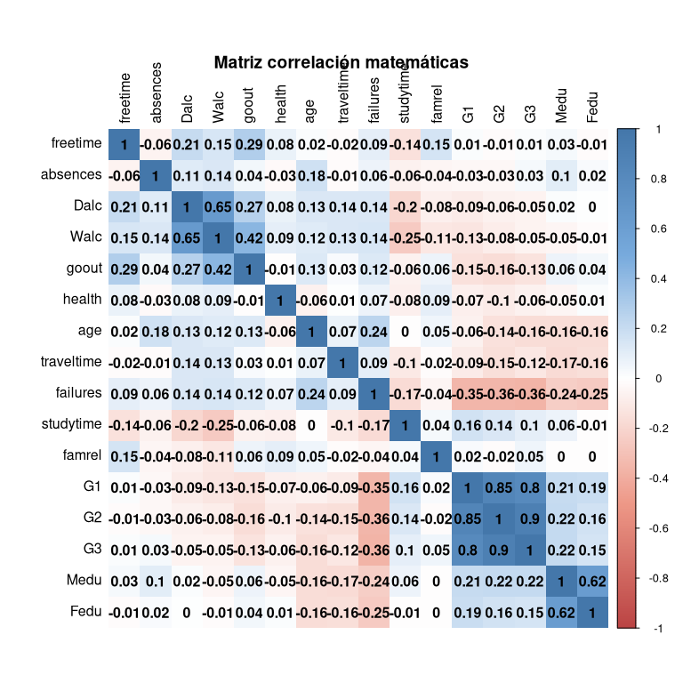

```r
mat.cor <- cor(mat1)

col <- colorRampPalette(c("#BB4444", "#EE9988", "#FFFFFF", "#77AADD", "#4477AA"))
corrplot(mat.cor, method="shade", shade.col=NA, tl.col="black", tlsrt=45, col=col(200), addCoef.col="black",
         order="AOE", mar=c(1,0,2,0), line=-2, main="Matriz correlación matemáticas")
```

```r
if(! "mlbench" %in% installed.packages()) install.packages("mlbench", depend=TRUE)
if(! "caret" %in% installed.packages()) install.packages("caret", depend=TRUE)
if(! "ROCR" %in% installed.packages()) install.packages("ROCR", depend=TRUE)
if(! "nloptr" %in% installed.packages()) install.packages("nloptr", depend=TRUE)

library(mlbench)
library(caret)
library(ROCR)
```

A continuación haremos una evaluación conjunta de los modelos kNN y SVM. El objetivo es predecir el valor numérico de la nota final (G3) considerando el conjunto de 15 variables del apartado anterior.

Antes que nada creamos dataset de entrenamiento y test:

```r
partition <- createDataPartition(mat1$G3, p=0.8, list=F)
train <- mat1[partition, ]
test <- mat1[-partition, ]

# Proporción de datos
#prop.table(table(train$G3))
#prop.table(table(test$G3))
```

Eliminamos las variables altamente correlacionadas y aquellas que tienen varianza cero (en este caso ninguna). También centramos y escalamos las variables para reducir la desviación.

```r
# Eliminamos variables con varianza cero.
zero.train <- nearZeroVar(train[, -dim(train)[2]], saveMetrics=F)
colnames(train)[zero.train]
```

character(0)

```r
# Y los que tienen alta correlación
cor.train <- cor(train[, -dim(train)[2]])
cor.train.index <- findCorrelation(cor.train, 0.8)
#cor.train.index
cor.train <- train[, -cor.train.index]
cor.test <- train[, -cor.train.index]

# Centrado y escalado. Variable objetivo
pre <- preProcess(cor.train[, -dim(cor.train)[2]])

train.prep <- predict(pre, cor.train[, -dim(cor.train)[2]])
train.prep$G3 <- cor.train$G3

test.prep <- predict(pre, cor.train[, -dim(cor.test)[2]])
test.prep$G3 <- cor.test$G3
```

En este punto ya podemos generar los modelos kNN y SVM:

```r
# Generación de modelo
knn.control <- trainControl(method="repeatedcv", repeats = 5)
svm.control <- trainControl(method="repeatedcv", repeats = 5)

# Entrenamos modelo knn
knn.mat1.model <- train(x=train.prep[, -dim(train.prep)[2]], y=train.prep$G3, method="knn",
                        tuneLength=10, trControl=knn.control)
knn.mat1.model
```

k-Nearest Neighbors

318 samples 14 predictor

No pre-processing Resampling: Cross-Validated (10 fold, repeated 5 times) Summary of sample sizes: 288, 286, 287, 286, 285, 287, … Resampling results across tuning parameters:

k RMSE Rsquared MAE  
5 3.268990 0.5160223 2.354724 7 3.291718 0.5140905 2.357452 9 3.289182 0.5286320 2.341271 11 3.310061 0.5340285 2.361080 13 3.322209 0.5358880 2.369466 15 3.322517 0.5421255 2.372389 17 3.338867 0.5443950 2.375616 19 3.353966 0.5473665 2.384601 21 3.356221 0.5534994 2.392389 23 3.367226 0.5574825 2.407036

RMSE was used to select the optimal model using the smallest value. The final value used for the model was k = 5.

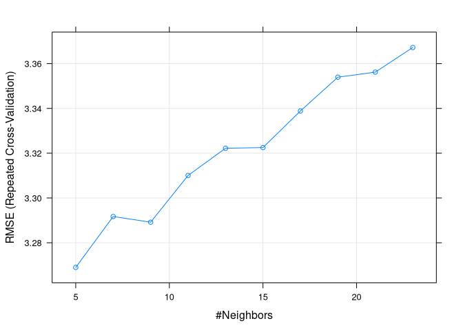

```r
print(plot(knn.mat1.model, metric="RMSE"))
```

```r
# Entrenamos modelo svm
svm.mat1.model <- train(x=train.prep[, -dim(train.prep)[2]], y=train.prep$G3, method="svmRadial",
                        tuneLength=10, trControl=svm.control)
svm.mat1.model
```

Support Vector Machines with Radial Basis Function Kernel

318 samples 14 predictor

No pre-processing Resampling: Cross-Validated (10 fold, repeated 5 times) Summary of sample sizes: 287, 286, 287, 286, 286, 286, … Resampling results across tuning parameters:

C RMSE Rsquared MAE  
0.25 2.967297 0.6592438 1.959213 0.50 2.847795 0.6567218 1.925631 1.00 2.793923 0.6493343 1.938032 2.00 2.844544 0.6294536 2.010517 4.00 2.936740 0.6009155 2.115604 8.00 3.041458 0.5745980 2.240181 16.00 3.159262 0.5475816 2.340371 32.00 3.250538 0.5272932 2.414416 64.00 3.272349 0.5230903 2.443769 128.00 3.327572 0.5112703 2.499453

Tuning parameter ‘sigma’ was held constant at a value of 0.05025628 RMSE was used to select the optimal model using the smallest value. The final values used for the model were sigma = 0.05025628 and C = 1.

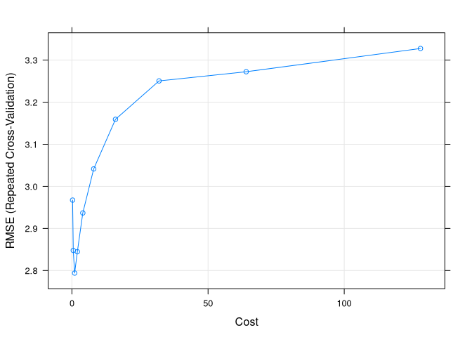

```r
print(plot(svm.mat1.model, metric="RMSE"))
```

Una vez conocidos los parámetros se muestra en pantalla una breve comparación de los resultados para la primeras observaciones:

```r
# Predicción sobre test
knn.mat1.test <- predict(knn.mat1.model, newdata=test.prep[, -dim(train.prep)[2]])
#knn.mat1.test

svm.mat1.test <- predict(svm.mat1.model, newdata=test.prep[, -dim(train.prep)[2]])
#svm.mat1.test

# Comparamos predicciones
knn.mat1.test.pred <- extractPrediction(list(model1=knn.mat1.model),
                                        testX = test.prep[, -dim(train.prep)[2]],
                                        testY = test.prep$G3)
knn.conjunto.test.preds <- subset(knn.mat1.test.pred, dataType=="Test")
#kable(head(knn.conjunto.test.preds))



svm.mat1.test.pred <- extractPrediction(list(model1=svm.mat1.model),
                                        testX = test.prep[, -dim(train.prep)[2]],
                                        testY = test.prep$G3)
svm.conjunto.test.preds <- subset(svm.mat1.test.pred, dataType=="Test")
#kable(head(svm.conjunto.test.preds))

df <- bind_cols(knn.conjunto.test.preds, svm.conjunto.test.preds)
df <- select(df, -obs1, -object, -object1, -dataType, -dataType1, -model, -model1)
names(df) = c("obs", "kNN", "SVM")
kable(head(df, 5))
```

| obs | kNN | SVM |
| --- | --- | --- |
| 6 | 6.2 | 4.817773 |
| 6 | 8.2 | 5.685125 |
| 10 | 5.0 | 6.905607 |
| 15 | 14.8 | 15.189404 |
| 10 | 8.8 | 6.555928 |

```r
knn.final <- data.frame(obs=test.prep$G3, pred=knn.conjunto.test.preds$pred)
defaultSummary(knn.final)
```

```
 RMSE  Rsquared       MAE
```

2.7421701 0.6632868 1.9534591

```r
svm.final <- data.frame(obs=test.prep$G3, pred=svm.conjunto.test.preds$pred)
defaultSummary(svm.final)
```

```
 RMSE  Rsquared       MAE
```

2.1571020 0.7982112 1.2735408

```r
svm.final <- data.frame(obs=test.prep$G3, pred=svm.conjunto.test.preds$pred)
defaultSummary(svm.final)
```

```
 RMSE  Rsquared       MAE
```

2.1571020 0.7982112 1.2735408

```r
models <- list(kNN=knn.mat1.model, SVM=svm.mat1.model)
summary(resamples(models))
```

Call: summary.resamples(object = resamples(models))

Models: kNN, SVM Number of resamples: 50

MAE Min. 1st Qu. Median Mean 3rd Qu. Max. NA’s kNN 1.39375 2.133073 2.336213 2.354724 2.574242 3.606061 0 SVM 1.44653 1.695349 1.892538 1.938032 2.109220 2.947686 0

RMSE Min. 1st Qu. Median Mean 3rd Qu. Max. NA’s kNN 1.846957 2.935461 3.215463 3.268990 3.719522 5.021288 0 SVM 1.956901 2.423352 2.712518 2.793923 3.118444 4.157399 0

Rsquared Min. 1st Qu. Median Mean 3rd Qu. Max. NA’s kNN 0.1508602 0.4430123 0.5241737 0.5160223 0.5912963 0.7624166 0 SVM 0.4615204 0.5968523 0.6551328 0.6493343 0.7049679 0.8249352 0

Como es de esperar tenemos mejores resultados para el model SVM. A pesar de que no obtenemos un ‘Rsquared’ cercano a 1, nuestros modelos logran capturar la esencia de la diversidad de datos arrojando buenos resultados. Una posible mejora sería limitar aún más el número de variables predictoras así como transformar el target a binario: si G3<10 = ‘fail’ & G3>10 = ‘pass’, lo que haría nuestros modelos más restringidos.

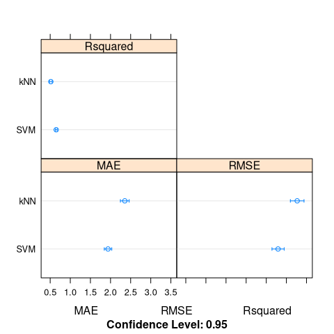

```r
dotplot(resamples(models))
```